# Training Status Augments Mechanisms of Forearm Rapid Vasodilation In Healthy Adults

Matthew Stanford

2025-12-16

## Introduction

Exercise performance requires an increase in oxygenated blood flow to skeletal muscles involved in the task. With sub-adequate oxygenation, fatigue onset will occur more quickly. Oxygenated blood flow to a specific region can be simplified to the equation: blood flow = arterio-venous pressure gradient*vascular conductance. The a-v pressure gradient is directly modulated by the heart, through an increase in stroke volumn and/or heart rate. Vascular conductance is modulated in the local tissue region where skeletal muscle activity is occuring. VC can be considered analogous to vessel diameter (vasodilation/vasoconstriction). Rapid vasodilation (ROV) is a feedforward mechanism to increase blood flow which is quantified using vascular conductance.

Exercise training has been shown to improve efficacy of certian physiological mechanisms related to blood flow. Thus far, ROV has only been assessed in relation to exercise training in older adults, where it is likely that a history of endurance training augments ROV compared to older, untrained adults. Whether ROV can adapt in a young healthy population is unknown.

We hypothesized that trained subjects would display greater peak and total changes in forearm vascular conductance (FVC) in response to 1-second stimuli compared to sedentary counterparts.

## Methods - Brief Experimental Design

Subjects were considered trained based on adhering to a minimum training frequency/intensity, which included forearm specific training, for at least 6 months immediately prior to study enrollment. Subjects were considered sedentary based on achieving a score of <600 MET minutes on the International Physical Activity Questionnaire (IPAQ), a standardized physical activity screening document, in addition to not performing any forearm specific training in the last 6 months immediately prior to study enrollment. All subjects were considered healthy via a medical questionnaire.

This study aimed to assess potential influences in forearm training status on different mechanisms of ROV in young healthy adults. We utilized voluntary and electrically-stimulated involuntary contractions, in addition to mechanical compression, to assess chemical, mechanical, and neural mechanisms of ROV. Forearm-trained subjects were paired with sedentary healthy subjects, based on sex, age, and height. All stimuli were applied for 1 second, with a minimum of 2 minutes of rest in between. All stimuli were applied 1 time per set in 2 sets of randomized stimuli for each subject. Randomization was performed to reduce impact of an order effect of stimuli, although analysis from pilot data in the study confirmed an order effect was not present. This study was a single-blind design.

Stimuli included: voluntary contractions against a resistance of 20% and 100% of a subject’s maximal voluntary contraction force, absolute resistances of 5, 10, 15kg, involuntary contractions via electrical stimulation of the ulnar nerve at 5mA and 10mA, 2.56ms pulse width, 100Hz, and mechanical compression of the forearm via pneumatic cuff at 50, 200, 300mmHg.

Forearm blood flow was calculated using brachial artery blood velocity and diameter, as measured via doppler ultrasound. FVC was calculated by dividing forearm blood flow by mean arterial pressure, measured via finger photoplethysmography. Delta FVC was calculated hearbeat-to-heartbeat for 30 heartbeats immediately post stimulus as the difference between beat-to-beat FVC (post-stimulus) and the average beat-to-beat FVC during rest (pre-stimulus).

2 outcome variables were assessed:

-Peak delta FVC, considered to be the highest delta FVC value observed in 30 heartbeats post-stimulus.

-Total delta FVC, considered to be the area under the delta FVC curve over 30 heartbeats post-stimulus.

## Analysis

Initial data processing for individual subjects, in order to generate outcome varialbes, occured in excel, a necessity due to inherent limitations in physiological assessment within living humans. Outcome variables for all stimulus intensities for each subject were then compiled in an excel file. The excel file located in the folder along with this Rmd document is a subset of the larger file. It contains the mechanical compression stimulus intensities and associated columns used for the analyses in this Rmd document.

# Packages loaded

Packages include: tidyverse readxl dplyr ggplot2 Hmisc afex car stats rstatix coin effsize knitr

# Dataset with delta FVC total values for compression intensities only

Delta FVC total values are in the unit ml/100mmHg, per standard practice.

```r
mmHg <- read.csv('mmHg_deltaFVC_total.csv')
```

# Pivot the data set to long format for analysis

```r
mmHg_long <- mmHg %>%
  pivot_longer(
    cols = c(mmHg300_FVC, mmHg200_FVC, mmHg50_FVC),
    names_to  = "intensity_original",
    values_to = "delta_fvc"
  ) %>%
  mutate(
    intensity = dplyr::recode(intensity_original,
                              "mmHg300_FVC"  = "300",
                              "mmHg200_FVC" = "200",
                              "mmHg50_FVC" = "50"),
    intensity = factor(intensity, levels = c("50","200","300")),
    Training_Status = factor(Training_Status, levels = c("trained","sedentary"))
  )
```

# Statistical Analysis Rationale

Pre-design power analysis using limited existing research resulted in a sample size of 20 subjects per group needed to achieve a power of 0.8 via independent, between-group mean comparisons (t-test). Strict inclusion/exclusion criteria as well as subject matching were implemented to reduce inter and intragroup variance. In-vivo human-subject studies in exercise physiology are likely to encounter considerable notable interindividual variance in physiological responses, necessitating careful statistical interpretation.

Comparions were made between groups using independent, one-tailed t-tests for main outcome variables (delta FVC peak and total). In the instance of a violation in normality (assessed via the Shapiro-Wilk test) and/or presentation of heterogeneity of variance (assessed via Levene’s test), Mann-Whitney tests were used as a non-parametric equivalent. Mann-Whitney compares value ranks between groups and is thus resistant to large outliers. It allows for the statement of whether or not the trained group demonstrated greater delta FVC values compared to the sedentary group, in general.

An interaction between main effects of stimulus intensity and training status was assessed via a 2-way, repeated- measures ANOVA.

Due to small sample sizes, emphasis is placed on effect sizes, although statistical significance dictates placement, or lack there-of, of asterisks over individual pairs of mean bars, seen in barplots later in this document.

For effect size, Cohen’s d was used for independent t-tests, r for Mann-Whitney, partial-eta squared for Training_status:Intensity interactions.

Significance was set to <= 0.05 for all tests.

Cohen’s d was interpreted as: small = 0.2 moderate = 0.5 large = 0.8

Effect size r was interpreted as: small = 0.1 moderate = 0.3 large = 0.5

Partial eta-squared was interpreted as: small = 0.01 moderate = 0.06 large = 0.14

# Function to output Shapiro-wilk test scores

| intensity | training_status | p_value |
| --- | --- | --- |
| 50 | trained | 0.944 |
| 200 | trained | 0.741 |
| 300 | trained | 0.843 |
| 50 | sedentary | 0.764 |
| 200 | sedentary | 0.144 |
| 300 | sedentary | 0.110 |

# Function to ouput Levene’s test scores

| intensity | p_value |
| --- | --- |
| 50 | 0.716 |
| 200 | 0.355 |
| 300 | 0.340 |

# Function to output independent t-test and Mann-Whitney test results

If shapiro-wilk and/or Levene’s test results are statistically significant, assess significance via Mann-Whitney. Otherwise, assess significance via independent t-test.

Output table labels: tt_p = t-test p-value, d = cohen’s d (t-test effect size), mw_p = mann-whitney test p-value, r = mann-whitney test effect size

```r
between_groups_compare <- function(df_long_name){
  ttest_combo_piece <- function(df_long_name){
    df_long_name %>%
      dplyr::group_by(intensity) %>%
      dplyr::summarize(
        tt_p = t.test(delta_fvc ~ Training_Status, alternative = 'greater')$p.value,
        d = cohens_d(delta_fvc ~ Training_Status, data = cur_data())$effsize,
        tt_n = dplyr::n(),
        .groups = 'drop'
      )

  }

  mann_whitney_test_combo_piece <- function(df_long_name){
    df_long_name %>%
      dplyr::group_by(intensity) %>%
      dplyr::summarize(
        mw_p = wilcox.test(delta_fvc ~ Training_Status)$p.value,
        r = wilcox_effsize(delta_fvc ~ Training_Status, data = cur_data())$effsize,
        mw_n = dplyr::n(),
        .groups = 'drop'
      )

  }

  tt_table <- ttest_combo_piece(df_long_name)
  mw_table <- mann_whitney_test_combo_piece(df_long_name)
  combined_group_comparison <- dplyr::full_join(tt_table, mw_table, by = "intensity")

  return(combined_group_comparison)
}
```

| intensity | tt_p | d | tt_n | mw_p | r | mw_n |
| --- | --- | --- | --- | --- | --- | --- |
| 50 | 0.186 | 0.462 | 16 | 0.382 | 0.236 | 16 |
| 200 | 0.096 | 0.687 | 16 | 0.328 | 0.263 | 16 |
| 300 | 0.049 | 0.892 | 16 | 0.195 | 0.341 | 16 |

# ANOVA function to output training_status:intensity interaction

|  | num Df | den Df | MSE | F | pes | Pr(>F) |
| --- | --- | --- | --- | --- | --- | --- |
| Training_Status:intensity | 1.58 | 22.123 | 14.287 | 1.191 | 0.078 | 0.312 |

# Template to generate a barplot of group-mean comparisons

Gray scale bar plot with a visible top-half of error bars, and individual subject data values overlaid on bars. Asterisks over bar pairs indicate a significant difference between trained and sedentary subjects for delta FVC total.

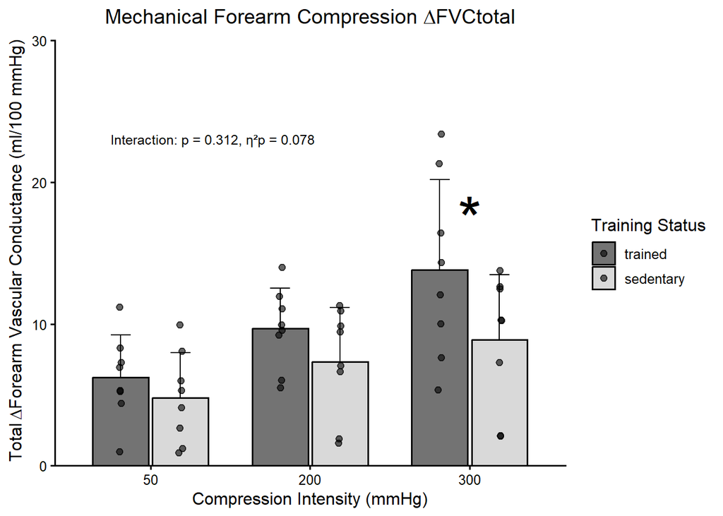

## Results

Trained subjects displayed greater delta FVC total in response to a 300mmHg forearm compression, compared to sedentary subjects. Near-moderate and moderate Cohen’s d for 50mmHg and 200mmHg suggest that group differences would be elucidated at lower intensities with a larger sample size. There was no training_status:intensity interaction for mechanical compression, although a moderate effect size suggests, likewise, this may be observed with a larger sample size.

## Discussion

NOTE: As this document only outputs results for one test of several from the project, please refer to the powerpoint ‘ROV pres’ for additional results and the condensed discussion.